# Overfitting and Underfitting

## Why models

- **to generalize well**
- avoiding high bias (underfitting)
- avoiding high variance (overfitting)

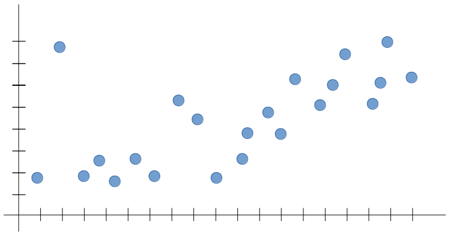

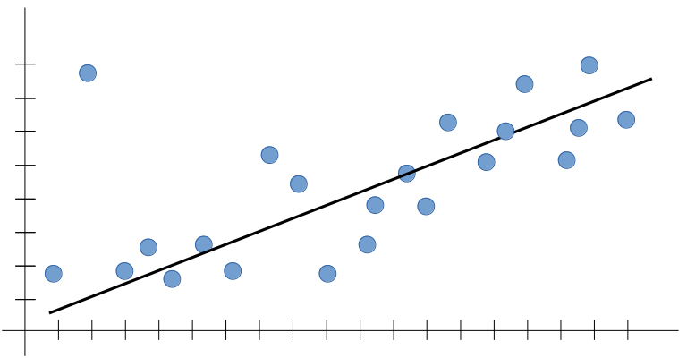

## Over and underfitting

- overfitting
- all trends captured
- not the dominant one

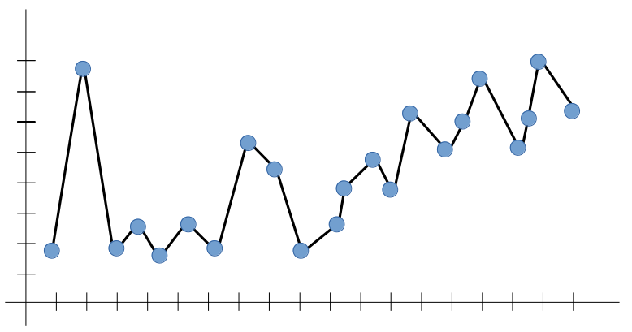

- underfitting
- not capturing any trend
- not the dominant one

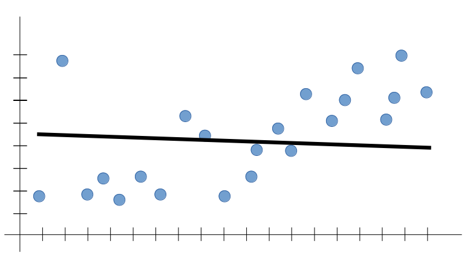

## Overfitting - 1

- the essence of an algorithm like Linear Regression is to capture the dominant trend and fit our line within that trend
- overfitting is the case where the overall cost is really small, but the generalization of the model is unreliable. This is due to the model learning *too much* from the training data set
- learned very well from from the training data
- can’t make reliable predictions for new inputs

## Overfitting - 2

- increase training data
- reduce model complexity
- early stopping during the training phase (have an eye over the loss over the training period as soon as loss begins to increase stop training)
- Ridge Regularization and Lasso Regularization
- use dropout for neural networks to tackle overfitting

[figure not shown]

## Overfitting - 3

- detecting:
  - good performance on the training data, poor generalization to other data

## Underfitting - 1

- just as bad for generalization of the model as overfitting
- underfitting is the case where the model has *not learned enough* from the training data, resulting in low generalization and unreliable predictions
- a simplistic line that does not generalize well

## Underfitting - 2

- increase model complexity
- increase number of features, performing feature engineering
- remove noise from the data.
- increase the number of epochs or increase the duration of training to get better results

[figure not shown]

## Underfitting - 3

- detecting:
  - poor performance on the training data, poor generalization to other data

## Splitting data

- splitting data to training and testing dataset
- usually 80:20, 70:30 splitting
- k-fold splitting, usually 9:1

## Splitting data - Python - 1

```python
import pandas as pd

url='https://raw.githubusercontent.com/TrainingByPackt/Data-Science-with-Python/master/Chapter01/Data/USA_Housing.csv'

df = pd.read_csv(url, header=0)
X = df.drop('Price', axis=1)

X.head()
```

```
##    Avg. Area Income  ...                                            Address
## 0      79545.458574  ...  208 Michael Ferry Apt. 674\nLaurabury, NE 3701...
## 1      79248.642455  ...  188 Johnson Views Suite 079\nLake Kathleen, CA...
## 2      61287.067179  ...  9127 Elizabeth Stravenue\nDanieltown, WI 06482...
## 3      63345.240046  ...                          USS Barnett\nFPO AP 44820
## 4      59982.197226  ...                         USNS Raymond\nFPO AE 09386
##
## [5 rows x 6 columns]
```

```python
X.shape
```

```
## (5000, 6)
```

## Splitting data - Python - 2

```python
from sklearn.model_selection import  train_test_split
y = df['Price']
X_train, X_test, y_train, y_test = train_test_split(X, y, test_size=0.2, random_state=0)

print("X_train : ",X_train.shape)
```

```
## X_train :  (4000, 6)
```

```python
print("X_test : ",X_test.shape)
```

```
## X_test :  (1000, 6)
```

```python
print("y_train : ",y_train.shape)
```

```
## y_train :  (4000,)
```

```python
print("y_test : ",y_test.shape)
```

```
## y_test :  (1000,)
```

## Splitting data - R - 1

```r
library(rsample)

url<-'https://raw.githubusercontent.com/TrainingByPackt/Data-Science-with-Python/master/Chapter01/Data/USA_Housing.csv'

df<-read.csv(url)

df_split <- initial_split(df, prop = 0.8)
df_split
```

```
## <Analysis/Assess/Total>
## <4001/999/5000>
```

## Splitting data - R - 2

```r
library(rsample)
library(tidyverse)

df_train<-training(df_split)
df_test<-testing(df_split)
X_train<-df_train%>%select(-'Price')
y_train<-df_train%>%select('Price')

X_test<-df_test%>%select(-'Price')
y_test<-df_test%>%select('Price')
```

## Unbalanced target variable

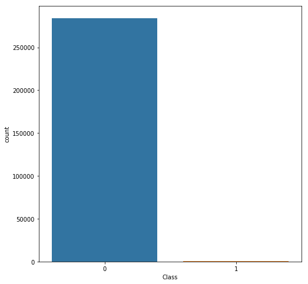

## What to do

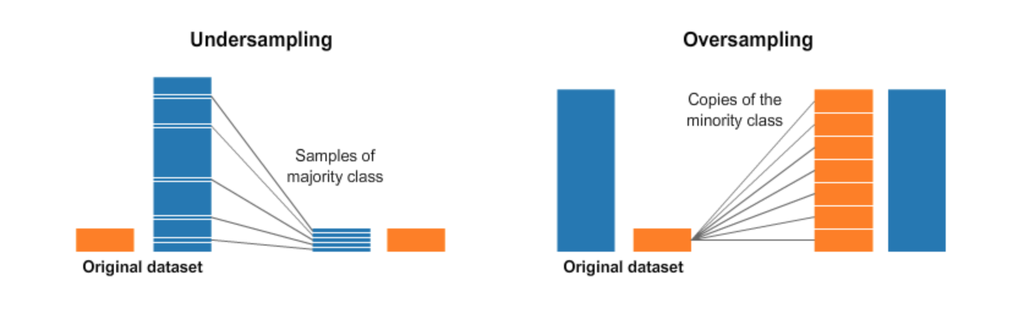

- undersampling is the process where you randomly delete some of the observations from the majority class in order to match the numbers with the minority class
- oversampling is the process of generating synthetic data that tries to randomly generate a sample of the attributes from observations in the minority class
- a number of methods used to oversample, e.g. SMOTE

## Naive over and undersampling

- random oversampling: randomly duplicate examples in the minority class
- random rndersampling: randomly delete examples in the majority class
- they assume nothing about the data and no heuristics are used
- both techniques can be used for two-class (binary) classification problems and multi-class classification problems with one or more majority or minority classes

## Naive oversampling - Python - 1

```python
from collections import Counter
from sklearn.datasets import make_classification
from imblearn.over_sampling import RandomOverSampler
# define dataset
X, y = make_classification(n_samples=10000, weights=[0.99], flip_y=0)

print(Counter(y))
```

```
## Counter({0: 9900, 1: 100})
```

## Naive oversampling - Python - 2

```python
# define oversampling strategy
oversample = RandomOverSampler(sampling_strategy='minority')
# fit and apply the transform
X_over, y_over = oversample.fit_resample(X, y)
# summarize class distribution
print(Counter(y_over))
```

```
## Counter({0: 9900, 1: 9900})
```

## Naive undersampling - Python - 1

```python
from imblearn.under_sampling import RandomUnderSampler

X, y = make_classification(n_samples=10000, weights=[0.99], flip_y=0)

print(Counter(y))
```

```
## Counter({0: 9900, 1: 100})
```

```python
undersample = RandomUnderSampler(sampling_strategy='majority')
# fit and apply the transform
X_over, y_over = undersample.fit_resample(X, y)
# summarize class distribution
print(Counter(y_over))
```

```
## Counter({0: 100, 1: 100})
```

## Naive oversampling - R - 1

```r
library(ROSE)

data(hacide)
table(hacide.train$cls)
```

```
##
##   0   1
## 980  20
```

```r
prop.table(table(hacide.train$cls))
```

```
##
##    0    1
## 0.98 0.02
```

## Naive oversampling - R - 2

```r
library(rpart)

data_balanced_over <- ovun.sample(cls ~ ., data = hacide.train,
method = "over",N = 1960)$data

table(data_balanced_over$cls)
```

```
##
##   0   1
## 980 980
```

## Naive undersampling - R - 1

```r
data_balanced_under <- ovun.sample(cls ~ ., data = hacide.train,
method = "under", N = 40, seed = 1)$data
table(data_balanced_under$cls)
```

```
##
##  0  1
## 20 20
```

## Lab

- use hacide.train dataset
- for pyhton use:

```python
url='https://raw.githubusercontent.com/urosgodnov/datasets/master/Hacide_train.csv'
data = pd.read_csv(url)
```

- explore dataset
- identify duplicate rows

## SMOTE

- Synthetic Minority Over-sampling Technique
- creates new observations along the lines of a randomly chosen point and its nearest neighbors

## SMOTE - Python

```python
import pandas as pd
from collections import Counter
from imblearn.over_sampling import SMOTE

url="https://raw.githubusercontent.com/urosgodnov/datasets/master/Hacide_train.csv"
data=pd.read_csv(url)
data_clean=data.iloc[:,1:4]
sm = SMOTE(sampling_strategy='auto', k_neighbors=2)

X = data_clean.iloc[:, 1:3]
y = data_clean.iloc[:,0]

X_res, y_res = sm.fit_resample(X, y)

print(Counter(y_res))
```

```
## Counter({0: 980, 1: 980})
```

## SMOTE - R

```r
library(DMwR)

data(hacide)
table(hacide.train$cls)
```

```
##
##   0   1
## 980  20
```

```r
hacidSMOTE <- SMOTE(cls ~ ., hacide.train,k=2, perc.over = 100, perc.under=200)

table(hacidSMOTE$cls)
```

```
##
##  0  1
## 40 40
```

## Lab

- use R in Python
- use hacide.train dataset
- calculate the averages of independent variables
- perform SMOTE analysis on hacide.train dataset
- calculate the averages of the “new” independent variables